# ewok_week_912

Eric Walker

September 12, 2016

## Kalman Filter EM algorithm

The Expectation Maximization algorithm for estimating parameters consists of a two-step process whereby a probability distribution over a weighted set of all possible completions of missing data is guessed using the current estimates of the parameters (E-step) and then this is used to create a new estimate of the parameters by maximizing the expected log-likelihood (M-step). These steps are repeated in an alternating fashion until the difference between the new estimates and the previous estimates falls below a specified threshold.

I used the following equation for the likelihood:

$$\frac{T}{2}log|Q^{-1}|-\frac{1}{2}Tr\left(Q^{-1}\left(\sum_{t=0}^{T-1}\left(\textbf{x}_{t+1}-A\textbf{x}_t\right)\left(\textbf{x}_{t+1}-A\textbf{x}_t\right)^T\right)\right)+\frac{T+1}{2}log|R^{-1}|-\frac{1}{2}Tr\left(R^{-1}\left(\sum_{t=0}^T\left(\textbf{y}_t-C\textbf{x}_t\right)^T\left(\textbf{y}_t-C\textbf{x}_t\right)^T\right)\right)$$

```r
# kalman_uni_em.R
# Created by Ewok on 2016-09-11
# Email: ewalke31@jhu.edu
# Copyright (c) 2016. All rights reserved.
#
# An implementation of a univariate Expectation Maximization Kalman Filter algorithm.
#
# Inputs:
#   y[t]
#     - the observed data
#     - univariate, t timesteps
#   a, c, q, r, pi, v
#     - initial parameter values
#     - state transition, generative, state noise, output noise, state mean, covariance
#   max_i
#     - maximum number of iterations before cut-off
#     - default of 20
#   tol
#     - minimum difference between iterations before cut-off
#     - default of 0.01
#
# Outputs:
#   A, C, Q, R, Pi, V
#     - final parameter estimations
#     - equivalent to respectively named inputs
#   Sx
#     - kalman smoothed values
#   lik
#     - log likelihood
#
kalman_uni_em <- function(y, a, c, q, r, pi, v, max_i=20, tol=0.01) {

  A <- a
  C <- c
  Q <- q
  R <- r
  Pi <- pi
  V <- v
  n <- length(y)  # number of timesteps
  i <- 1  # iteration
  diff <- 1  # difference between iterations
  Pt <- vector(, n)
  Ptt_1 <- vector(, n-1)
  lik <- vector(, max_i)

  while (i <= max_i && diff > tol) {

    #  E Step:
    s <- KFSu(A, C, Q, R, Pi, V, y)
    for (t in 1:n) {
      Pt[t] <- s$Sv[t]+s$Sx[t]*s$Sx[t]
      if (t != n) {
        Ptt_1[t] <- s$Scov[t]+s$Sx[t+1]*s$Sx[t]
      }
    }
    like = (n/2)*log(1/Q)-0.5*(1/Q)*sum((s$Fx2-A*s$Fx1)^2)+((n+1)/2)*log(1/R)-0.5*(1/R)*sum((y-C*s$Fx1)^2)
    lik[i] <- log(like)

    #  M Step:
    C_new <- sum(y*s$Sx) / sum(Pt)
    R_new <- (sum(y*y)-sum(C_new*s$Sx*y)) / n
    A_new <- sum(Ptt_1) / sum(Pt[1:n-1])
    Pi_new <- s$Sx[1]
    Q_new <- 1  # constraint
    V_new <- V  # constraint

    # updates
    diff <- abs(C_new-C)+abs(R_new-R)+abs(A_new-A)+abs(Q_new-Q)+abs(Pi_new-Pi)+abs(V_new-V)
    i <- i+1
    A <- A_new
    C <- C_new
    Q <- Q_new
    R <- R_new
    Pi <- Pi_new
    V <- V_new
  }
  lik=lik[lik!=0]
  return(list(A=A, C=C, Q=Q, R=R, Pi=Pi, V=V, Sx=s$Sx, lik=lik))
}
```

For some reason, the C matrix does not seem to be converging to the correct value, and it is messing up the results.

Consider the following example, where the initial state mean is started at the correct value:

The red line is the actual sine curve, the blue is after 3 iterations, and the black is after 100.

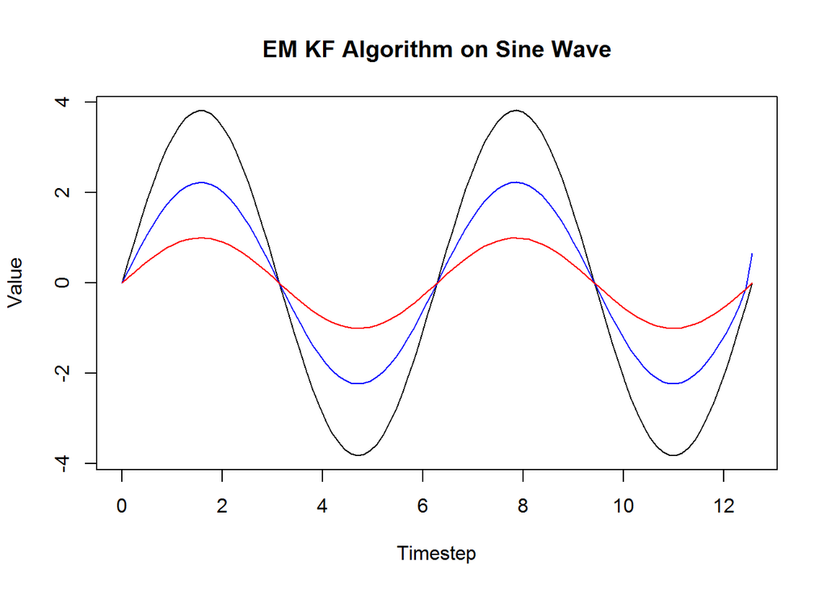

```r
t <- seq(0,4*pi,,100)
actual <- sin(t)
x1 <- kalman_uni_em(actual, 1, 1, 1, 1, 0, 0, 100, 0.0001)
x2 <- kalman_uni_em(actual, 1, 1, 1, 1, 0, 0, 3, 0.01)
plot(t, x1$Sx, main="EM KF Algorithm on Sine Wave", xlab="Timestep", ylab="Value", type="l")
lines(t, x2$Sx, col="blue")
lines(t, actual, col="red")
```

```r
print(x1)
```

```
## $A
## [1] 0.9914803
##
## $C
## [1] 0.2615227
##
## $Q
## [1] 1
##
## $R
## [1] 0.0002377383
##
## $Pi
## [1] 0
##
```

[output cut: 41 more lines]

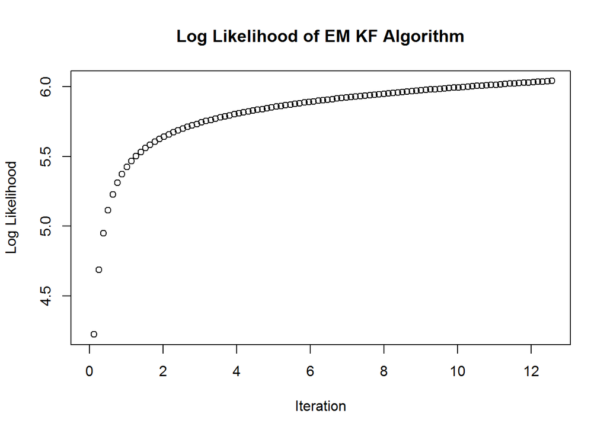

```r
plot(t, x1$lik, main="Log Likelihood of EM KF Algorithm", xlab="Iteration", ylab="Log Likelihood")
```

Clearly, something is going wrong. The C matrix has a value of 0.262 when its ideal value is 1. This seems to be causing the amplification by a factor of approximately 4. As the number of iterations increases, so does the amplification, maxing out around 4.

The error appears to persist even with a straight line:

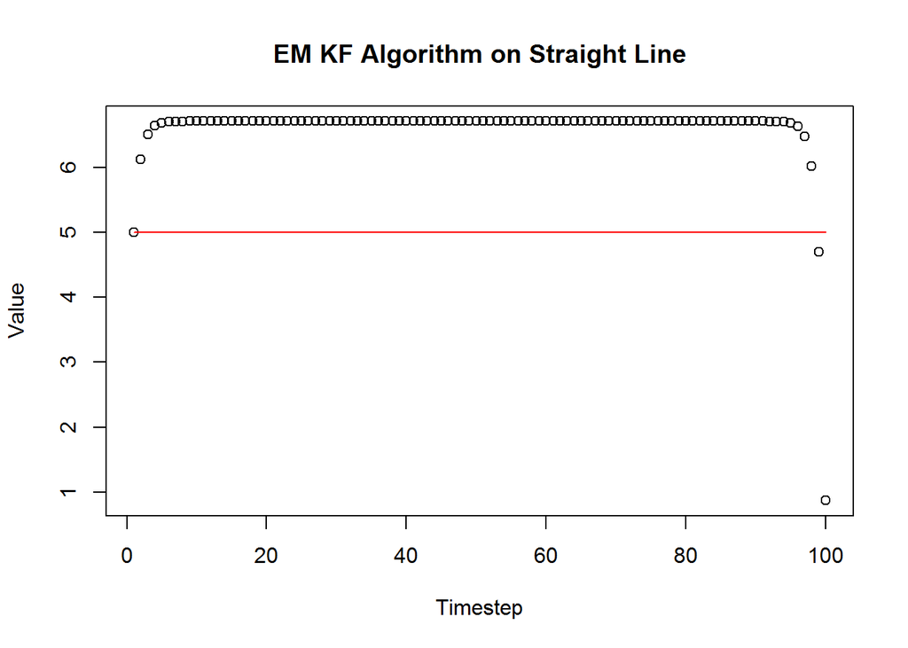

```r
t <- 1:100
series <- rep(5,100)
x <- kalman_uni_em(series, 1, 1, 1, 1, 5, 0, 100, 0.0001)
plot(t, x$Sx, main="EM KF Algorithm on Straight Line", xlab="Timestep", ylab="Value")
lines(t, series, col="red")
```

```r
print(c(x$A, x$C, x$Q, x$R))
```

```
## [1] 0.9895029 0.7446538 1.0000000 0.4513306
```